# Stat490_HW5

Janine Yanes

```r
knitr::opts_chunk$set(results = 'asis')
#Load packages
library(knitr)
library(kableExtra)
library(tidyverse)
library(combinat)
library(AlgDesign)
library(tgp)
```

```r
data = read.csv("star_data.csv")
# data for GPA year 2
var_name = c("GPA_year2","control","age","dad_edn","mom_edn", "sfsp","ssp","sfp", "female")
data2 = data[,var_name]
ind2 = which(is.na(data2$GPA_year2)==0)
data2 = data2[ind2,]
```

## Part (i)

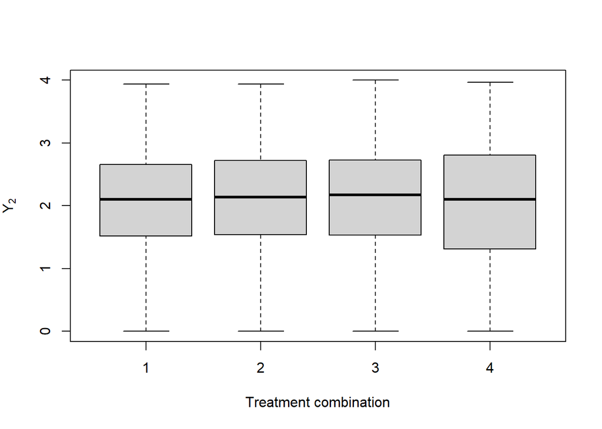

```r
y2=data2$GPA_year2

# Getting w vector
N=length(y2)
w=numeric(N)
w[data2$control==1]=1 # ssp=0, sfp=0
w[data2$sfp==1]=2 # ssp=0, sfp=1
w[data2$ssp==1]=3 # ssp=1, sfp=0
w[data2$sfsp==1]=4 # ssp=1, sfp=1

# Display of data
boxplot(y2 ~ w, xlab="Treatment combination", ylab=expression(Y[2]))
```

## Part (ii)

```r
# ANOVA using lm()
n1=sum(w==1)
n2=sum(w==2)
n3=sum(w==3)
n4=sum(w==4)
anova(lm(y2 ~ factor(w)))
```

```
## Analysis of Variance Table
##
## Response: y2
##             Df Sum Sq Mean Sq F value Pr(>F)
## factor(w)    3    0.9 0.29865  0.3614 0.7809
## Residuals 1364 1127.1 0.82631
```

|  | Df | Sum Sq | Mean Sq | F value |
| --- | --- | --- | --- | --- |
| **Treatments** | 3 | 0.9 | 0.29865 | 0.3614 |
| **Residuals** | 1364 | 1127.1 | 0.82631 |  |
| **Total** | 1367 | 1128.0 | 1.12496 |  |

## Part (iii)

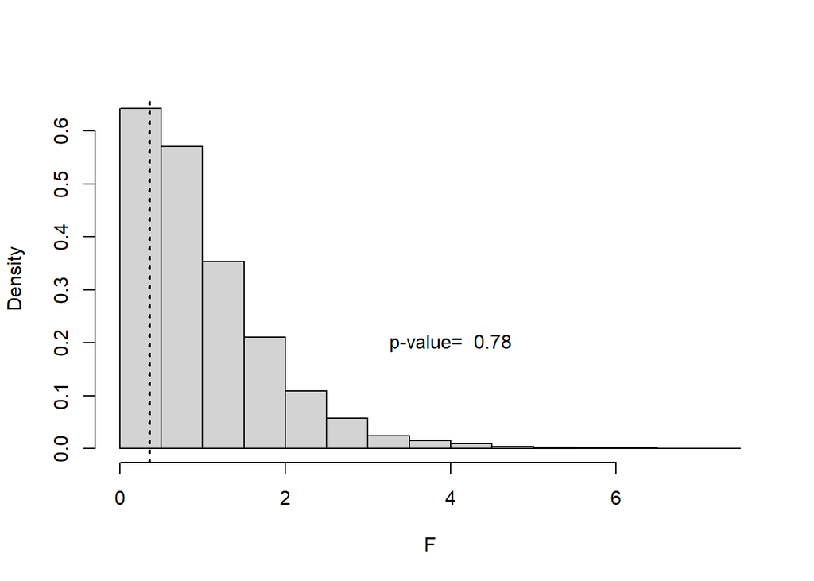

```r
StardataY2Ch6 = data.frame("w"=w,"y2"=y2)
N_j = StardataY2Ch6 %>% count(w) %>% .$n %>% as.integer()

D = gen.factorial(2,2) ## ME contrast columns in reverse order
D[, c(1:2)] = D[,c(2:1)] ## Reverse the order of the columns
colnames(D) = c("F1","F2")
L = model.matrix(~ F1 + F2 + F1*F2,D)
ITER=10000
Fobs=0.3614
Farray=NULL

set.seed(100)
for (count in 1:ITER) {
wnew = sample(c(rep(1,N_j[1]),rep(2,N_j[2]),
              rep(3,N_j[3]),rep(4,N_j[4])))

Fnew=anova(lm(y2 ~ factor(wnew)))$F[1]
Farray = c(Farray, Fnew)
}
hist(Farray, main=NULL, freq=FALSE, xlab="F")
abline(v=Fobs, lty=3, lwd=2)
pvalF = sum(Farray >= Fobs)/ITER
text(4,0.2,paste("p-value= ",round(pvalF,2)))
```

Given the high p-value, we conclude that none of the treatments are effective.

## Part (iv)

```r
twosqimpute = function(y,w,tau1=0,tau2=0,tau3=0){
  N = length(y)
  Data = tibble(y=y,w=w)
  N_j = Data %>% count(w) %>% .$n
  beta = c(tau1/2, tau2/2, tau3/2)
  genPOT = matrix(c(rep(0,N*4)), ncol=4)
  # L matrix
  D = gen.factorial(2,2) ## ME contrast columns in reverse order
  D[, c(1:2)] = D[,c(2:1)] ## Reverse the order of the columns
  colnames(D) = c("F1","F2")
  L = model.matrix(~ F1 + F2 + F1*F2,D)
  L_indexed = matrix(cbind(c(1:4),L), ncol=5)
  for (i in 1:N) {
    genPOT[i,w[i]] = y[i]
    Lobs = L_indexed[w[i],-c(1:2)] # 1x3 row vector
    tau0 = y[i] - t(Lobs) %*% beta # estimate average of the unit
    Lmis = L_indexed[-w[i],]
    trmis = L_indexed[-w[i],1]
    Ymis = Lmis[,-1] %*% c(tau0, beta) # impute missing outcomes
    for (j in 1:3) {
      genPOT[i,trmis[j]] = Ymis[j]
    }
  }
  return(genPOT)
}

#Using Tscaled as the test statistic
Fishertesttwosquare = function(y,w,tau1,tau2,tau3,ITER) {
  N = length(y)
  Data = tibble(y=y,w=w)
  N_j = Data %>% count(w) %>% .$n
  ybarvector = Data %>% group_by(w) %>%
  summarize(ybar=mean(y)) %>% .$ybar
  n1=sum(w==1)
  n2=sum(w==2)
  n3=sum(w==3)
  n4=sum(w==4)
  meanvec = c(mean(y[w==1]),mean(y[w==2]),mean(y[w==3]),mean(y[w==4]))
  varvec = c(var(y[w==1]),var(y[w==2]),var(y[w==3]),var(y[w==4]))
  MSRes = ((n1-1)*varvec[1]+(n2-1)*varvec[2]+(n3-1)*varvec[3]+(n4-1)*varvec[4])/(N-4)
  VNey=MSRes*(1/n1 + 1/n2 + 1/n3 + 1/n4)/4
  SE = sqrt(VNey)
  # L matrix
  D = gen.factorial(2,2) ## ME contrast columns in reverse order
  D[, c(1:2)] = D[,c(2:1)] ## Reverse the order of the columns
  colnames(D) = c("F1","F2")
  L = model.matrix(~ F1 + F2 + F1*F2,D)
  Yimp = twosqimpute(y,w,tau1, tau2, tau3) # Imputed matrix
  taubarhatadj = (t(L) %*% ybarvector)/4
  taubarhat = 2*taubarhatadj[2:4] # adjust factorial effects by 2
  Tscaled=abs(taubarhat/SE)
  Tscaled1obs= Tscaled[1]
  Tscaled2obs= Tscaled[2]
  Tscaled3obs= Tscaled[3]
  Tscaled1array=Tscaled2array = Tscaled3array = NULL
  # for any one factorial effect
  for (count in 1:ITER) {
    wnew = sample(c(rep(1,N_j[1]),rep(2,N_j[2]),rep(3,N_j[3]),rep(4,N_j[4])))
    ynew = numeric(N)
    for (i in 1:N) {
      ynew[i]=Yimp[i,wnew[i]]
    }
    n1new=sum(wnew==1)
    n2new=sum(wnew==2)
    n3new=sum(wnew==3)
    n4new=sum(wnew==4)
    meanvecnew = c(mean(ynew[wnew==1]),mean(ynew[wnew==2]),mean(ynew[wnew==3]),mean(ynew[wnew==4]))
    varvecnew = c(var(ynew[wnew==1]),var(ynew[wnew==2]),var(ynew[wnew==3]),var(ynew[wnew==4]))
    MSResnew = ((n1new-1)*varvecnew[1]+(n2new-1)*varvecnew[2]+(n3new-1)*varvecnew[3]+(n4new-1)*varvecnew[4])/(N-4)
    VNeynew=MSResnew*(1/n1new + 1/n2new + 1/n3new + 1/n4new)/4
    SEnew = sqrt(VNeynew)
    ybarvectornew = NULL
    for (j in 1:4) {
      ybarvectornew = c(ybarvectornew,mean(ynew[wnew==j]))
    }
    taubarhatadjnew = (t(L) %*% ybarvectornew)/4
    Tscaled1new = (2*taubarhatadjnew[2])/SEnew
    Tscaled2new = (2*taubarhatadjnew[3])/SEnew
    Tscaled3new = (2*taubarhatadjnew[4])/SEnew
    Tscaled1array = c(Tscaled1array,Tscaled1new)
    Tscaled2array = c(Tscaled2array,Tscaled2new)
    Tscaled3array = c(Tscaled3array,Tscaled3new)
  }
  #one-sided p-values
  pval1plus = sum(Tscaled1array >= Tscaled1obs)/ITER
  pval2plus = sum(Tscaled2array >= Tscaled2obs)/ITER
  pval3plus = sum(Tscaled3array >= Tscaled3obs)/ITER
  pval1minus = sum(Tscaled1array <= Tscaled1obs)/ITER
  pval2minus = sum(Tscaled2array <= Tscaled2obs)/ITER
  pval3minus = sum(Tscaled3array <= Tscaled3obs)/ITER
  #two-sided p-values
  pval1both = sum(abs(Tscaled1array) >= abs(Tscaled1obs))/ITER
  pval2both = sum(abs(Tscaled2array) >= abs(Tscaled2obs))/ITER
  pval3both = sum(abs(Tscaled3array) >= abs(Tscaled3obs))/ITER
  return(list(pvalplus = c(pval1plus, pval2plus, pval3plus),
  pvalminus = c(pval1minus, pval2minus, pval3minus),
  pvalboth = c(pval1both, pval2both, pval3both)))
}

set.seed(100)
Fishertesttwosquare(y2,w,0,0,0,10000)
```

```
## $pvalplus
## [1] 0.4156 0.4531 0.1616
##
## $pvalminus
## [1] 0.5844 0.5469 0.8384
##
## $pvalboth
## [1] 0.8361 0.8917 0.3257
```

Given the high p-values for all three factorial effects (for both the one-sided and two-sided tests), we conclude that none of the effects are significant; the treatments are neither harmful nor helpful.

```r
#Looking at estimated effects
meanvec = c(mean(y2[w==1]),mean(y2[w==2]),mean(y2[w==3]),mean(y2[w==4]))
varvec = c(var(y2[w==1]),var(y2[w==2]),var(y2[w==3]),var(y2[w==4]))
MSRes = ((n1-1)*varvec[1]+(n2-1)*varvec[2]+(n3-1)*varvec[3]+(n4-1)*varvec[4])/(N-4)
VNey=MSRes*(1/n1 + 1/n2 + 1/n3 + 1/n4)/4
SE = sqrt(VNey)
taubarhatadj = (t(L) %*% meanvec)/4
taubarhat = 2*taubarhatadj[2:4] # adjust factorial effects by 2
Tscaled=abs(taubarhat/SE)
pval=2*(1-pnorm(abs(Tscaled)))

cbind(taubarhat, rep(SE,3), Tscaled, pval)
```

```
##         taubarhat              Tscaled      pval
## [1,] -0.012744094 0.06250941 0.2038748 0.8384513
## [2,] -0.008422171 0.06250941 0.1347345 0.8928218
## [3,] -0.061851298 0.06250941 0.9894718 0.3224324
```

## Part (v)

```r
F1int = c(taubarhat[1]-qnorm(p=.05/2, lower.tail=FALSE)*SE, taubarhat[1]+qnorm(p=.05/2, lower.tail=FALSE)*SE)
F1int
```

```
## [1] -0.1352603  0.1097721
```

```r
F2int = c(taubarhat[2]-qnorm(p=.05/2, lower.tail=FALSE)*SE, taubarhat[2]+qnorm(p=.05/2, lower.tail=FALSE)*SE)
F2int
```

```
## [1] -0.1309384  0.1140940
```

```r
F3int = c(taubarhat[3]-qnorm(p=.05/2, lower.tail=FALSE)*SE, taubarhat[3]+qnorm(p=.05/2, lower.tail=FALSE)*SE)
F3int
```

```
## [1] -0.18436749  0.06066489
```

## Part (vi)

### Female

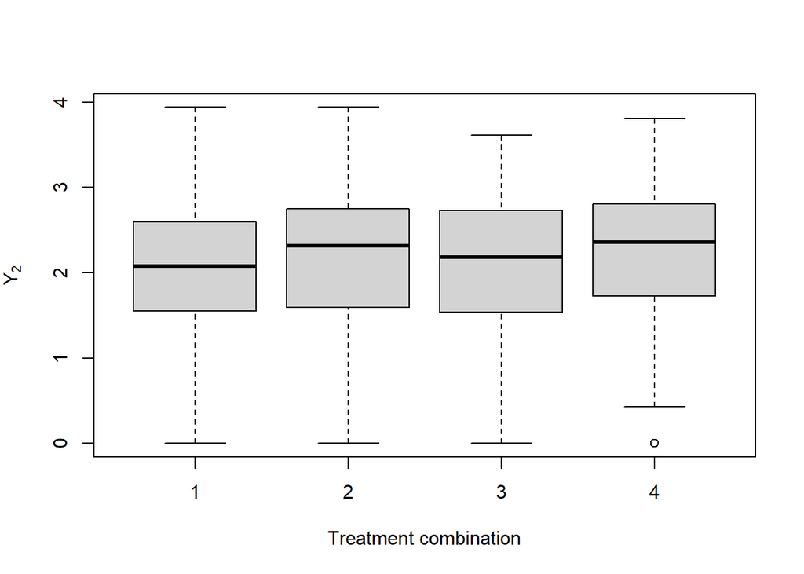

```r
data2f = subset(data2, female==1)
y2f=data2f$GPA_year2

# Getting w vector
N=length(y2f)
w=numeric(N)
w[data2f$control==1]=1 # ssp=0, sfp=0
w[data2f$sfp==1]=2 # ssp=0, sfp=1
w[data2f$ssp==1]=3 # ssp=1, sfp=0
w[data2f$sfsp==1]=4 # ssp=1, sfp=1

# Display of data
boxplot(y2f ~ w, xlab="Treatment combination", ylab=expression(Y[2]))
```

```r
# ANOVA using lm()
n1=sum(w==1)
n2=sum(w==2)
n3=sum(w==3)
n4=sum(w==4)
anova(lm(y2f ~ factor(w)))
```

```
## Analysis of Variance Table
##
## Response: y2f
##            Df Sum Sq Mean Sq F value Pr(>F)
## factor(w)   3   3.67 1.22479   1.616 0.1842
## Residuals 775 587.37 0.75789
```

|  | Df | Sum Sq | Mean Sq | F value |
| --- | --- | --- | --- | --- |
| **Treatments** | 3 | 3.67 | 1.22479 | 1.616 |
| **Residuals** | 775 | 587.37 | 0.75789 |  |
| **Total** | 778 | 591.04 | 1.98268 |  |

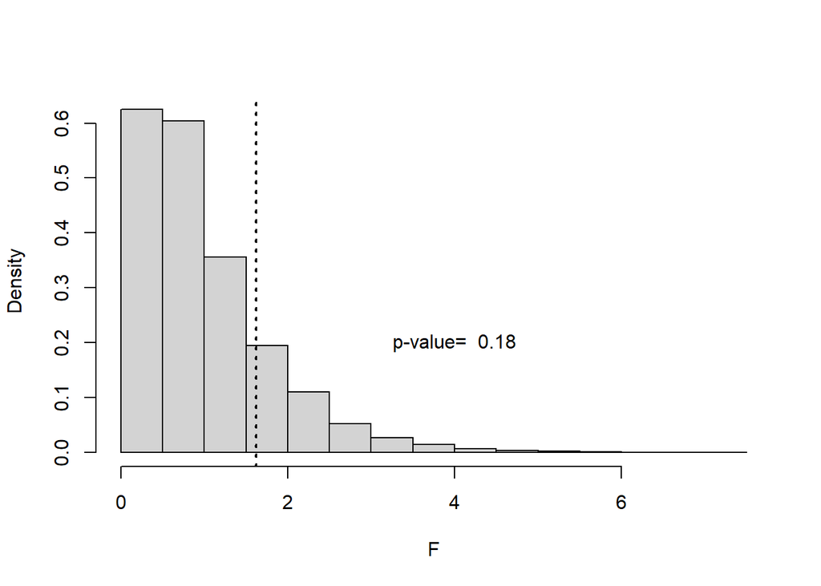

```r
StardataY2fCh6 = data.frame("w"=w,"y2f"=y2f)
N_j = StardataY2fCh6 %>% count(w) %>% .$n %>% as.integer()

D = gen.factorial(2,2) ## ME contrast columns in reverse order
D[, c(1:2)] = D[,c(2:1)] ## Reverse the order of the columns
colnames(D) = c("F1","F2")
L = model.matrix(~ F1 + F2 + F1*F2,D)
ITER=10000
Fobs=1.616
Farray=NULL

set.seed(100)
for (count in 1:ITER) {
wnew = sample(c(rep(1,N_j[1]),rep(2,N_j[2]),
              rep(3,N_j[3]),rep(4,N_j[4])))

Fnew=anova(lm(y2f ~ factor(wnew)))$F[1]
Farray = c(Farray, Fnew)
}
hist(Farray, main=NULL, freq=FALSE, xlab="F")
abline(v=Fobs, lty=3, lwd=2)
pvalF = sum(Farray >= Fobs)/ITER
text(4,0.2,paste("p-value= ",round(pvalF,2)))
```

While the p-value is much lower than the one for both males and females, it is still fairly high (considering that common values for $\alpha$ are 0.1 or 0.05). As a result, we conclude that none of the treatments are effective for females.

```r
set.seed(100)
Fishertesttwosquare(y2f,w,0,0,0,10000)
```

```
## $pvalplus
## [1] 0.1725 0.0478 0.4636
##
## $pvalminus
## [1] 0.8275 0.9522 0.5364
##
## $pvalboth
## [1] 0.3498 0.0914 0.9209
```

Looking at the one-sided p-values, we see that factor SFP has a p-value of 0.0478 for the test with the alternative hypothesis $H_A:\bar\tau(F_2)>0$. Given this low p-value, we conclude that factor SFP has a positive effect on GPA for females.

```r
#Looking at estimated effects
meanvec = c(mean(y2f[w==1]),mean(y2f[w==2]),mean(y2f[w==3]),mean(y2f[w==4]))
varvec = c(var(y2f[w==1]),var(y2f[w==2]),var(y2f[w==3]),var(y2f[w==4]))
MSRes = ((n1-1)*varvec[1]+(n2-1)*varvec[2]+(n3-1)*varvec[3]+(n4-1)*varvec[4])/(N-4)
VNey=MSRes*(1/n1 + 1/n2 + 1/n3 + 1/n4)/4
SE = sqrt(VNey)
taubarhatadj = (t(L) %*% meanvec)/4
taubarhat = 2*taubarhatadj[2:4] # adjust factorial effects by 2
Tscaled=abs(taubarhat/SE)
pval=2*(1-pnorm(abs(Tscaled)))

cbind(taubarhat, rep(SE,3), Tscaled, pval)
```

```
##        taubarhat              Tscaled       pval
## [1,] 0.074779196 0.07991828 0.9356958 0.34942984
## [2,] 0.133869774 0.07991828 1.6750833 0.09391788
## [3,] 0.008136608 0.07991828 0.1018116 0.91890622
```

```r
#Confidence intervals
F1int = c(taubarhat[1]-qnorm(p=.05/2, lower.tail=FALSE)*SE, taubarhat[1]+qnorm(p=.05/2, lower.tail=FALSE)*SE)
F1int
```

```
## [1] -0.08185775  0.23141614
```

```r
F2int = c(taubarhat[2]-qnorm(p=.05/2, lower.tail=FALSE)*SE, taubarhat[2]+qnorm(p=.05/2, lower.tail=FALSE)*SE)
F2int
```

```
## [1] -0.02276717  0.29050672
```

```r
F3int = c(taubarhat[3]-qnorm(p=.05/2, lower.tail=FALSE)*SE, taubarhat[3]+qnorm(p=.05/2, lower.tail=FALSE)*SE)
F3int
```

```
## [1] -0.1485003  0.1647736
```

### Male

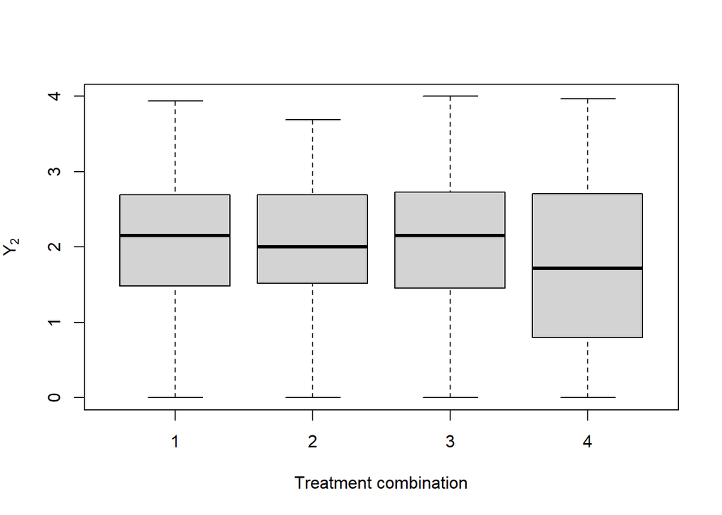

```r
data2m = subset(data2, female==0)
y2m=data2m$GPA_year2

# Getting w vector
N=length(y2m)
w=numeric(N)
w[data2m$control==1]=1 # ssp=0, sfp=0
w[data2m$sfp==1]=2 # ssp=0, sfp=1
w[data2m$ssp==1]=3 # ssp=1, sfp=0
w[data2m$sfsp==1]=4 # ssp=1, sfp=1

# Display of data
boxplot(y2m ~ w, xlab="Treatment combination", ylab=expression(Y[2]))
```

```r
# ANOVA using lm()
n1=sum(w==1)
n2=sum(w==2)
n3=sum(w==3)
n4=sum(w==4)
anova(lm(y2m ~ factor(w)))
```

```
## Analysis of Variance Table
##
## Response: y2m
##            Df Sum Sq Mean Sq F value Pr(>F)
## factor(w)   3   4.87 1.62325  1.7876 0.1483
## Residuals 585 531.22 0.90807
```

|  | Df | Sum Sq | Mean Sq | F value |
| --- | --- | --- | --- | --- |
| **Treatments** | 3 | 4.87 | 1.62325 | 1.7876 |
| **Residuals** | 585 | 531.22 | 0.90807 |  |
| **Total** | 588 | 536.09 | 2.53132 |  |

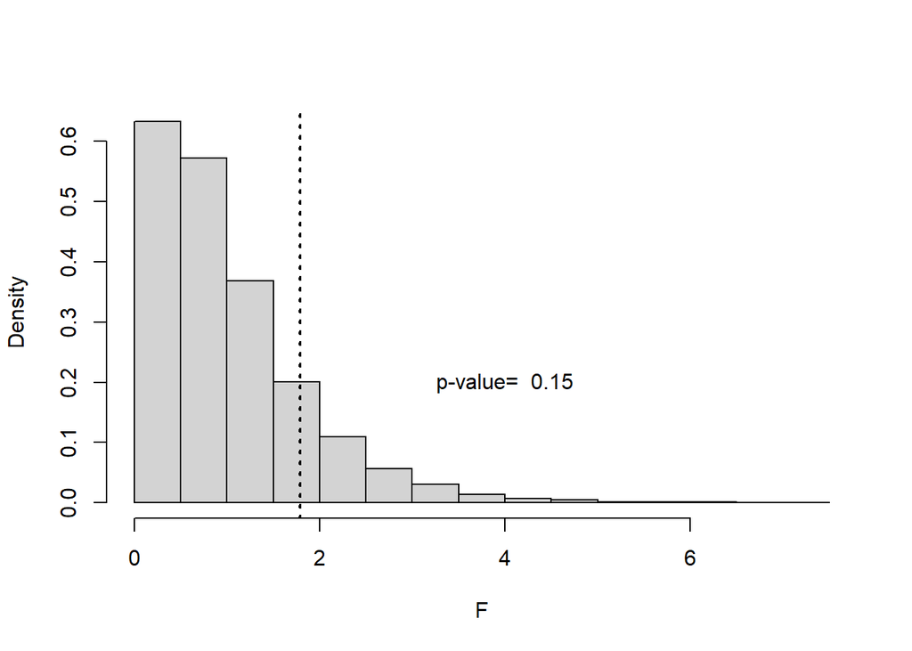

```r
Stardatay2mCh6 = data.frame("w"=w,"y2m"=y2m)
N_j = Stardatay2mCh6 %>% count(w) %>% .$n %>% as.integer()

D = gen.factorial(2,2) ## ME contrast columns in reverse order
D[, c(1:2)] = D[,c(2:1)] ## Reverse the order of the columns
colnames(D) = c("F1","F2")
L = model.matrix(~ F1 + F2 + F1*F2,D)
ITER=10000
Fobs=1.7876
Farray=NULL

set.seed(100)
for (count in 1:ITER) {
wnew = sample(c(rep(1,N_j[1]),rep(2,N_j[2]),
              rep(3,N_j[3]),rep(4,N_j[4])))

Fnew=anova(lm(y2m ~ factor(wnew)))$F[1]
Farray = c(Farray, Fnew)
}
hist(Farray, main=NULL, freq=FALSE, xlab="F")
abline(v=Fobs, lty=3, lwd=2)
pvalF = sum(Farray >= Fobs)/ITER
text(4,0.2,paste("p-value= ",round(pvalF,2)))
```

While the p-value is much lower than the one for both males and females, it is still fairly high. As a result, we conclude that none of the treatments are effective for males.

```r
set.seed(100)
Fishertesttwosquare(y2m,w,0,0,0,10000)
```

```
## $pvalplus
## [1] 0.1237 0.0301 0.0795
##
## $pvalminus
## [1] 0.8763 0.9699 0.9205
##
## $pvalboth
## [1] 0.2400 0.0572 0.1526
```

```r
#Looking at estimated effects
meanvec = c(mean(y2m[w==1]),mean(y2m[w==2]),mean(y2m[w==3]),mean(y2m[w==4]))
varvec = c(var(y2m[w==1]),var(y2m[w==2]),var(y2m[w==3]),var(y2m[w==4]))
MSRes = ((n1-1)*varvec[1]+(n2-1)*varvec[2]+(n3-1)*varvec[3]+(n4-1)*varvec[4])/(N-4)
VNey=MSRes*(1/n1 + 1/n2 + 1/n3 + 1/n4)/4
SE = sqrt(VNey)
taubarhatadj = (t(L) %*% meanvec)/4
taubarhat = 2*taubarhatadj[2:4] # adjust factorial effects by 2
Tscaled=abs(taubarhat/SE)
pval=2*(1-pnorm(abs(Tscaled)))

cbind(taubarhat, rep(SE,3), Tscaled, pval)
```

```
##       taubarhat            Tscaled       pval
## [1,] -0.1167992 0.0989824 1.180000 0.23800040
## [2,] -0.1889086 0.0989824 1.908507 0.05632576
## [3,] -0.1428299 0.0989824 1.442983 0.14902518
```

```r
#Confidence intervals
F1int = c(taubarhat[1]-qnorm(p=.05/2, lower.tail=FALSE)*SE, taubarhat[1]+qnorm(p=.05/2, lower.tail=FALSE)*SE)
F1int
```

```
## [1] -0.31080111  0.07720275
```

```r
F2int = c(taubarhat[2]-qnorm(p=.05/2, lower.tail=FALSE)*SE, taubarhat[2]+qnorm(p=.05/2, lower.tail=FALSE)*SE)
F2int
```

```
## [1] -0.382910495  0.005093364
```

```r
F3int = c(taubarhat[3]-qnorm(p=.05/2, lower.tail=FALSE)*SE, taubarhat[3]+qnorm(p=.05/2, lower.tail=FALSE)*SE)
F3int
```

```
## [1] -0.33683187  0.05117199
```